# Chapter 6: Analysis of longitudinal data

```r
date()
```

```
## [1] "Tue Dec  7 11:18:27 2021"
```

```r
# packages in use
library(dplyr)
library(ggplot2)
library(tidyr)
```

## 6.1 RATS

In this subchapter I will implement the analyses of Chapter 8 of MABS using the RATS data.

### 6.1.1 Data

The RATS data utilized here is drawn from a nutrition study conducted with rats ([see Crowder & Hand 1990](https://www.routledge.com/Analysis-of-Repeated-Measures/Crowder-Hand/p/book/9780367450847)). In the experiment the rats were grouped into three groups which had different diets, and each rat’s weight (grams) was recorded weekly over a 9-week period (with an exception of week seven when two measurements were taken).

The original RATS data included 16 observations of 13 variables, that is 16 rats with multiple measurements over time (and a few other variables). Here, the data is transformed from wide to long format by time (measurements), meaning that each time point (i.e. measurement) forms an observation and, thus, every individual rat has as many observations as there are measurements. Thererore, in the long format there are 176 observations of 4 variables, which are:

- ID: unique id of participants (rats)
- Group: the treatment groups 1, 2 and 3
- Weight: rat’s weight in grams
- Time: time point (days) of the weight measurement

*NB: The variable ‘WD’ is removed from the data set as its information is already included in the ‘Time’ variable and thus there is no use for it. In addition, ID and Group variables are transformed to factors.*

```r
# load the data in long format
rats_long <- read.table("data/rats_long.csv", sep = ";")

# prepare data for the analysis
## remove WD variable
## Group and ID -> factors
rats_long <- rats_long %>%
  dplyr::select(-WD) %>%
  mutate(Group = as.factor(Group),
         ID = as.factor(ID))

str(rats_long)
```

```
## 'data.frame':    176 obs. of  4 variables:
##  $ ID    : Factor w/ 16 levels "1","2","3","4",..: 1 2 3 4 5 6 7 8 9 10 ...
##  $ Group : Factor w/ 3 levels "1","2","3": 1 1 1 1 1 1 1 1 2 2 ...
##  $ Weight: int  240 225 245 260 255 260 275 245 410 405 ...
##  $ Time  : int  1 1 1 1 1 1 1 1 1 1 ...
```

```r
head(rats_long)
```

```
##   ID Group Weight Time
## 1  1     1    240    1
## 2  2     1    225    1
## 3  3     1    245    1
## 4  4     1    260    1
## 5  5     1    255    1
## 6  6     1    260    1
```

```r
glimpse(rats_long)
```

```
## Rows: 176
## Columns: 4
## $ ID     <fct> 1, 2, 3, 4, 5, 6, 7, 8, 9, 10, 11, 12, 13, 14, 15, 16, 1, 2, 3,…
## $ Group  <fct> 1, 1, 1, 1, 1, 1, 1, 1, 2, 2, 2, 2, 3, 3, 3, 3, 1, 1, 1, 1, 1, …
## $ Weight <int> 240, 225, 245, 260, 255, 260, 275, 245, 410, 405, 445, 555, 470…
## $ Time   <int> 1, 1, 1, 1, 1, 1, 1, 1, 1, 1, 1, 1, 1, 1, 1, 1, 8, 8, 8, 8, 8, …
```

### 6.1.2 Graphical examination of the group based differences

First, I draw a plot for every observed rat; the plot shows measured weight (y-axis) over time (x-axis) for every rat (lines). Rats in every group have gained weight during the experiment, although the growth seems to be bigger in groups 2 and 3 compared to group 1. However, the plot also illustrates that in the beginning of the experiment (time 1) the rats differ from each other in terms of the weight and bigger rats are bigger throughout the experiment. Rats in group 1 are much smaller than those in the groups 2 and 3. Also there is one much bigger individual in the group 2.

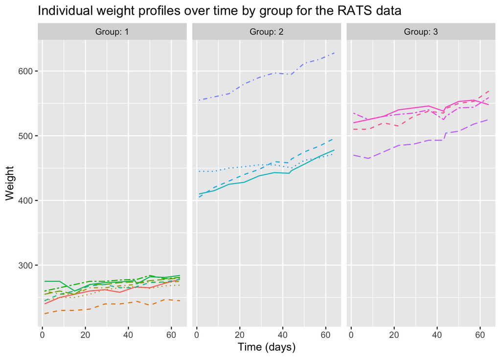

```r
# Draw a plot for rats in each group over time
ggplot(rats_long, aes(x = Time, y = Weight, linetype = ID, col = ID)) +
  geom_line() +
  scale_linetype_manual(values = rep(1:8, times=4)) + #what this does?
  facet_grid(. ~ Group, labeller = label_both) +
  theme(legend.position = "none") +
  scale_y_continuous(limits = c(min(rats_long$Weight), max(rats_long$Weight))) +
  ggtitle("Individual weight profiles over time by group for the RATS data") +
  xlab("Time (days)")
```

Next, I will standardize/center the weight variable and repeat the above-presented graphical examination. The graphical results are similar, although the trend in weight gain does not seem to be as straightforward as in the previous plot, especially regarding group 3.

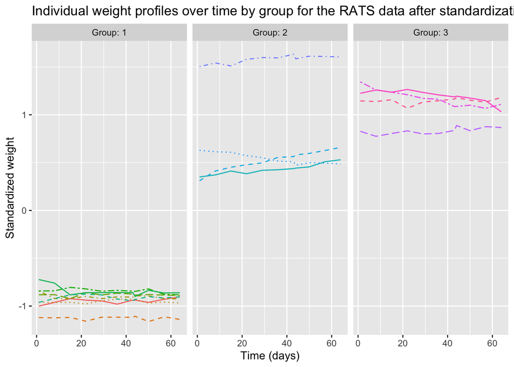

```r
# Standardize the variable weight
rats_long<- rats_long %>%
  group_by(Time) %>%
  mutate(Weight_std = (Weight - mean(Weight)) / sd(Weight)) %>%
  ungroup()

# Draw the plot using the stardardixed weight variable
ggplot(rats_long, aes(x = Time, y = Weight_std, linetype = ID, col = ID)) +
  geom_line() +
  scale_linetype_manual(values = rep(1:8, times=4)) + #what this does?
  facet_grid(. ~ Group, labeller = label_both) +
  theme(legend.position = "none") +
  scale_y_continuous(name = "Standardized weight") +
  ggtitle("Individual weight profiles over time by group for the RATS data after standardization") +
  xlab("Time (days)")
```

To get a better picture of the weight gain and the differences between the groups, I will next produce a graph showing average profiles for each group. Additionally I draw a graph showing side-by-side box plots of the observations at each time point. The graphs illustrate that every group has gained weight over time, although the weight gain is a bit different in different groups. The figures also show that the mean weights of groups 2 and 3 clearly differ from group 1. In addition, although there is some overlap between the groups 2 and 3 profiles it seems that they do differ from each other. Moreover, the box plots suggest the presence of multiple possible outliers at a number of time points.

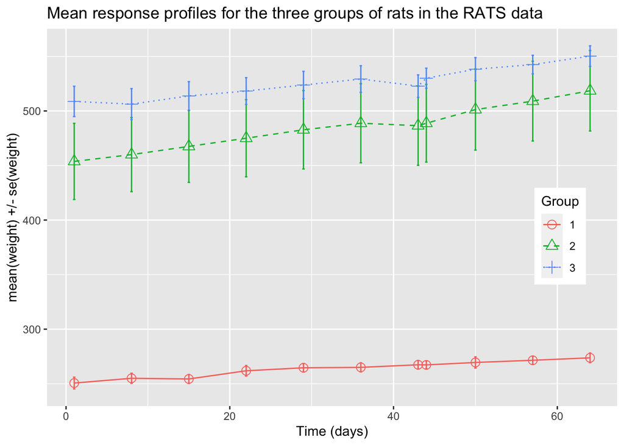

```r
# Summary data with mean and standard error of weight by treatment group and time

# Note: DIFFRENT NUMBER OF RATS IN DIFFERENT GROUPS!
## use function n() inside sqrt(); n() gives the current group size
rats_long_s <- rats_long %>%
  group_by(Group, Time) %>%
  summarise(mean = mean(Weight), se = sd(Weight) /  sqrt(n())) %>%
  ungroup()

# Plot the mean profiles
ggplot(rats_long_s , aes(x = Time, y = mean, linetype = Group, shape = Group, col = Group)) +
  geom_line() +
  scale_linetype_manual(values = c(1,2,3)) +
  geom_point(size=3) +
  scale_shape_manual(values = c(1,2,3)) +
  geom_errorbar(aes(ymin=mean-se, ymax=mean+se, linetype="1"), width=0.3) +
  theme(legend.position = c(0.9,0.45)) +
  scale_y_continuous(name = "mean(weight) +/- se(weight)") +
  xlab("Time (days)") +
  ggtitle("Mean response profiles for the three groups of rats in the RATS data")
```

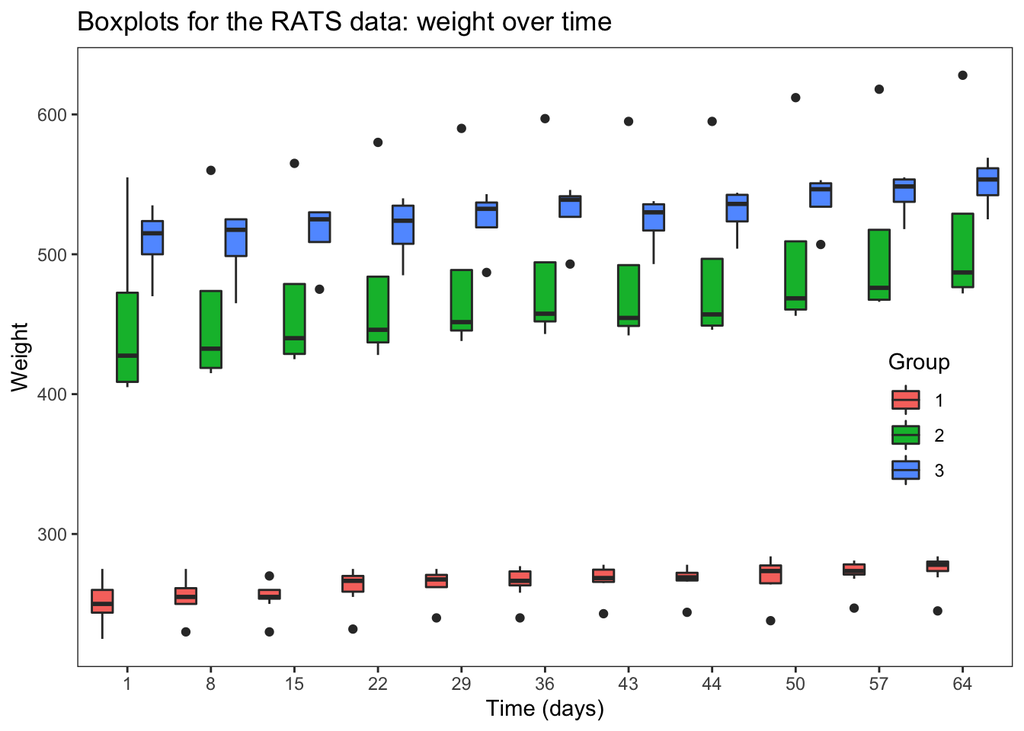

```r
# Alternative mean profile figure: side-by-side box plots of the observations at each time point
ggplot(rats_long, aes(x = as.factor(Time), y = Weight, fill = Group)) +
  geom_boxplot(position = position_dodge(width = 0.9)) +
  theme_bw() + theme(panel.grid.major = element_blank(), panel.grid.minor = element_blank()) +
  theme(legend.position = c(0.9,0.4)) +
  scale_x_discrete(name = "Time (days)") +
  ggtitle("Boxplots for the RATS data: weight over time")
```

I will continue the summary approach and look into the post-treatment values of the weight. The mean of weight (all weeks) will be the summary measure. Day 1 will be considered here as the baseline and it is excluded from the examination.

```r
# Create a summary data by group and subject with mean as the summary variable (ignoring baseline day 1).
rats_summary <- rats_long %>%
  filter(Time > 1) %>%
  group_by(Group, ID) %>%
  summarise( mean=mean(Weight) ) %>%
  ungroup()
```

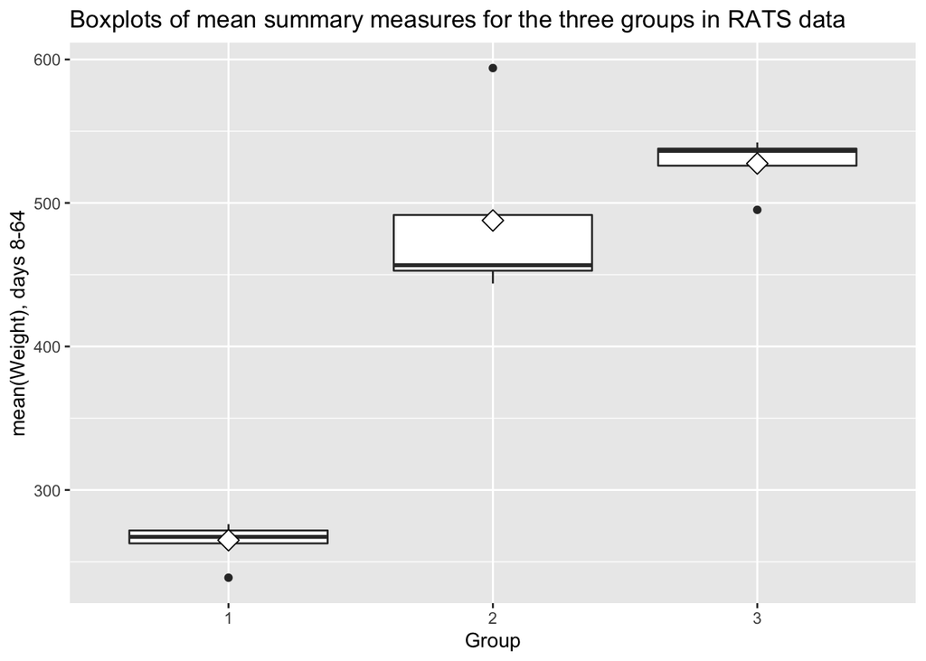

```r
# Draw a boxplot of the mean versus group
ggplot(rats_summary, aes(x = Group, y = mean)) +
  geom_boxplot() +
  stat_summary(fun = "mean", geom = "point", shape=23, size=4, fill = "white") +
  scale_y_continuous(name = "mean(Weight), days 8-64") +
  ggtitle("Boxplots of mean summary measures for the three groups in RATS data")
```

The box plots presented above shows again that the groups differ from each other and also that every group has an outlier, although only in the case of group two the outlier is quite far from the others. Thus, I will remove the outlier of group 2 and draw the box plots again. After removing the outlier, the differences between the groups are even clearer as can be seen in the picture below.

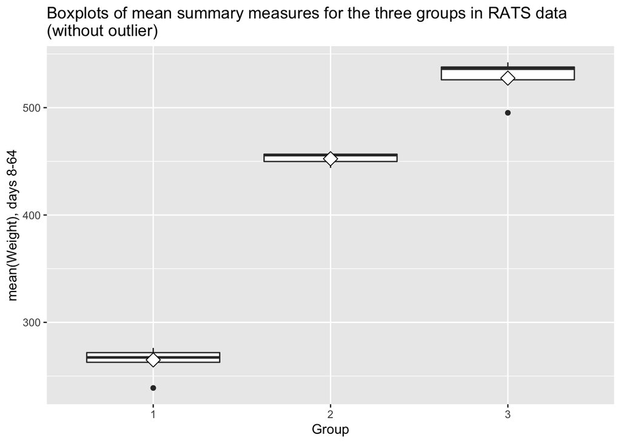

```r
rats_summary_filt <- rats_summary %>%
  filter(mean < 550)

# Draw a boxplot of the mean versus group
ggplot(rats_summary_filt, aes(x = Group, y = mean)) +
  geom_boxplot() +
  stat_summary(fun = "mean", geom = "point", shape=23, size=4, fill = "white") +
  scale_y_continuous(name = "mean(Weight), days 8-64") +
  ggtitle("Boxplots of mean summary measures for the three groups in RATS data \n(without outlier)")
```

### 6.1.3 Statistical examination of the group-based differences

Next, I will first fit a linear model with the mean weight as the response and group as the only explanatory variable. The results of the model are shown below.

```r
# Fit the linear model with the mean as the response and Group as explanatory
fit <- lm(mean ~ Group, data = rats_summary)
# summary of the fitted model
summary(fit)
```

```
##
## Call:
## lm(formula = mean ~ Group, data = rats_summary)
##
## Residuals:
##     Min      1Q  Median      3Q     Max
## -43.900 -27.169   2.325   9.069 106.200
##
## Coefficients:
##             Estimate Std. Error t value Pr(>|t|)
## (Intercept)   265.02      12.98  20.419 2.92e-11 ***
## Group2        222.77      22.48   9.909 2.00e-07 ***
## Group3        262.48      22.48  11.675 2.90e-08 ***
## ---
## Signif. codes:  0 '***' 0.001 '**' 0.01 '*' 0.05 '.' 0.1 ' ' 1
##
## Residual standard error: 36.71 on 13 degrees of freedom
## Multiple R-squared:  0.9316, Adjusted R-squared:  0.9211
## F-statistic: 88.52 on 2 and 13 DF,  p-value: 2.679e-08
```

```r
# analysis of variance table for the fitted model
anova(fit)
```

```
## Analysis of Variance Table
##
## Response: mean
##           Df Sum Sq Mean Sq F value    Pr(>F)
## Group      2 238620  119310  88.525 2.679e-08 ***
## Residuals 13  17521    1348
## ---
## Signif. codes:  0 '***' 0.001 '**' 0.01 '*' 0.05 '.' 0.1 ' ' 1
```

As can be seen from the summary table above, the positive regression coefficients of both groups are statistically significant (p < 0.001). Similarly, the analysis of variance (ANOVA) shows that the weight of the rats differ between the examined groups and that the result is highly significant (p < 0.001). Next, I will add the baseline measurement (day 1) from the original data to the summary data and include it as a covariate in the linear regression model. The results of the linear regression model and ANOVA are presented below.

```r
## load the data in wide form
rats_wide <- read.table("data/rats_wide.csv", sep = ";")

# Add the baseline (Day 1) from the original data as a new variable to the summary data
rats_summary2 <- rats_summary %>%
  mutate(baseline = rats_wide$WD1)

# Fit the linear model with the mean as the response
fit <- lm(mean ~ baseline + Group, data = rats_summary2)

# summary of the fitted model
summary(fit)
```

```
##
## Call:
## lm(formula = mean ~ baseline + Group, data = rats_summary2)
##
## Residuals:
##     Min      1Q  Median      3Q     Max
## -23.905  -4.194   2.190   7.577  14.800
##
## Coefficients:
##             Estimate Std. Error t value Pr(>|t|)
## (Intercept) 33.16375   21.87657   1.516   0.1554
## baseline     0.92513    0.08572  10.793 1.56e-07 ***
## Group2      34.85753   18.82308   1.852   0.0888 .
## Group3      23.67526   23.25324   1.018   0.3287
## ---
## Signif. codes:  0 '***' 0.001 '**' 0.01 '*' 0.05 '.' 0.1 ' ' 1
##
## Residual standard error: 11.68 on 12 degrees of freedom
## Multiple R-squared:  0.9936, Adjusted R-squared:  0.992
## F-statistic: 622.1 on 3 and 12 DF,  p-value: 1.989e-13
```

```r
# analysis of variance table for the fitted model
anova(fit)
```

```
## Analysis of Variance Table
##
## Response: mean
##           Df Sum Sq Mean Sq   F value   Pr(>F)
## baseline   1 253625  253625 1859.8201 1.57e-14 ***
## Group      2    879     439    3.2219  0.07586 .
## Residuals 12   1636     136
## ---
## Signif. codes:  0 '***' 0.001 '**' 0.01 '*' 0.05 '.' 0.1 ' ' 1
```

When taking the baseline into account results are quite different! According to the above presented results from the linear regression model, the coefficient of group 2 or 3 are not statistically significant (when considering p < 0.05 as the threshold). Analysis of variance provides similar results, indicating that the difference between the groups is not statistically significant when taking the baseline into account. Although, naturally these are only preliminary results and, for instance, the longitudinal structure of the data is ignored. More sophisticated and proper analysis of the data can be found in the chapter 9 of MABS.

## 6.2 BPRS

In this subchapter I will implement the analyses of Chapter 9 of MABS using the BPRS data.

### 6.2.1 Data

In this exercise I will use data taken from [Davis (2002)](https://link.springer.com/book/10.1007/b97287). The data is from an experimental study in which 40 males were randomly assigned to two treatment groups and each participant was rated on a psychiatric rating scale (BPRS) measured before the treatment started (week 0) and weekly after that for eight weeks. Here, the data is already transformed from wide to long form.

```r
# load the data in long format
bprs_long <- read.table("data/bprs_long.csv", sep = ";")

# prepare data for the analysis
## remove WD variable
## Group and ID -> factors
bprs_long <- bprs_long%>%
  dplyr::select(-weeks) %>%
  mutate(treatment = as.factor(treatment),
         subject = as.factor(subject),
         id = as.factor(id))

str(bprs_long)
```

```
## 'data.frame':    360 obs. of  5 variables:
##  $ treatment: Factor w/ 2 levels "1","2": 1 1 1 1 1 1 1 1 1 1 ...
##  $ subject  : Factor w/ 20 levels "1","2","3","4",..: 1 2 3 4 5 6 7 8 9 10 ...
##  $ id       : Factor w/ 40 levels "1","2","3","4",..: 1 2 3 4 5 6 7 8 9 10 ...
##  $ bprs     : int  42 58 54 55 72 48 71 30 41 57 ...
##  $ week     : int  0 0 0 0 0 0 0 0 0 0 ...
```

```r
summary(bprs_long)
```

```
##  treatment    subject          id           bprs            week
##  1:180     1      : 18   1      :  9   Min.   :18.00   Min.   :0
##  2:180     2      : 18   2      :  9   1st Qu.:27.00   1st Qu.:2
##            3      : 18   3      :  9   Median :35.00   Median :4
##            4      : 18   4      :  9   Mean   :37.66   Mean   :4
##            5      : 18   5      :  9   3rd Qu.:43.00   3rd Qu.:6
##            6      : 18   6      :  9   Max.   :95.00   Max.   :8
##            (Other):252   (Other):306
```

```r
head(bprs_long)
```

```
##   treatment subject id bprs week
## 1         1       1  1   42    0
## 2         1       2  2   58    0
## 3         1       3  3   54    0
## 4         1       4  4   55    0
## 5         1       5  5   72    0
## 6         1       6  6   48    0
```

BPRS data includes multiple measurements from 40 subjects. As the data is transformed from wide to long format by time (measurements), each time point forms an observation and, thus, every participant has as many observations as there are measurements. Note that the numbering of the subjects/participants goes from 1 to 20 in both treatment groups, which is why I have created a new id-variable into the data which goes from 1 to 40 identifying each participants ([see the R-Script for the coding of id-variable](https://github.com/Kuukkelipyy/IODS-project/blob/master/data/meet_and_repeat.R)). In the long form there are 360 observations of 5 variables, which are:

- treatment: the treatment groups 1 and 2
- subject: the id of participant in given treatment group (both groups have subjects from 1 to 20)
- id: unique id of the participants
- bprs: results of the measurements
- week: time point (weeks) of the measurements

NB: The variable ‘weeks’ is removed from the data set as its information is already included in the ‘week’ variable and thus there is no use for it. In addition, subject and treatment variables are transformed to factors.

### 6.2.2 Graphical examination

Let’s first take brief graphical examination of the data! I’ll begin by plotting the BPRS-ratings over time and identifying the treatment groups in which the observations belong while ignoring the longitudinal nature of the data (i.e. which subject’s observations are in question). The below-presented plot shows a downward trend in the BPRS-scores, especially regarding the first treatment group.

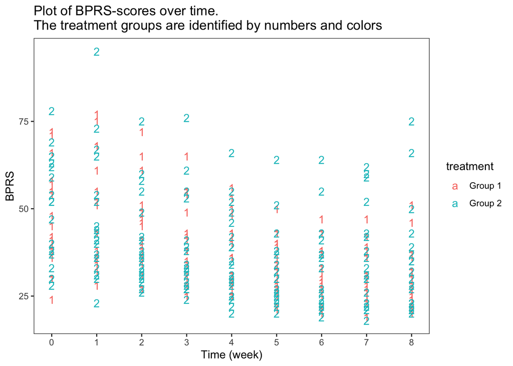

```r
ggplot(bprs_long, aes(x = week, y = bprs, group = id, col = treatment)) +
  geom_text(aes(label = treatment)) +
  scale_x_continuous(name = "Time (week)", breaks = seq(0, 11, 1)) +
  scale_colour_discrete(labels = c("Group 1", "Group 2")) +
  scale_y_continuous(name = "BPRS") +
  theme_bw() +
  theme(panel.grid.major = element_blank(), panel.grid.minor = element_blank()) +
  ggtitle("Plot of BPRS-scores over time.\nThe treatment groups are identified by numbers and colors")
```

Next, I will take the longitudinal nature of the data into account and draw a plot of individual BPRS profiles. The individual profiles show similar downward trend in the BPRS scores over time, although in the group 2 there seem to be more departures from this trend.

The next figure, that is the scatter plot matrix, demonstrates that the repeated measures of BPRS are not independent of one another, which is no surprise when considering the longitudinal nature of the data.

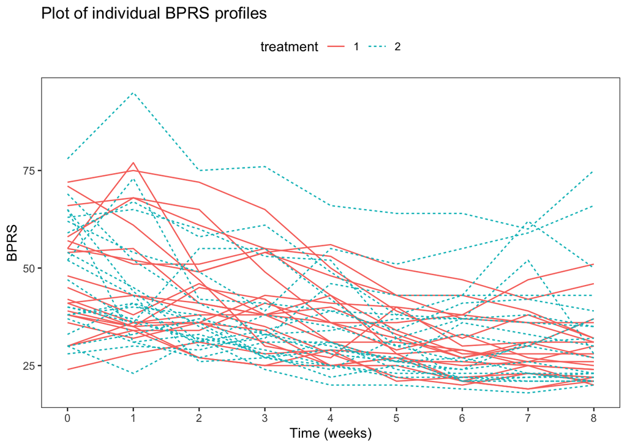

```r
# Plot the RATSL data
ggplot(bprs_long, aes(x = week, y = bprs, group = id, col = treatment)) +
  geom_line(aes(linetype = treatment)) +
  scale_x_continuous(name = "Time (weeks)", breaks = seq(0, 11, 1)) +
  scale_y_continuous(name = "BPRS") +
  theme_bw() + theme(legend.position = "top") +
  theme(panel.grid.major = element_blank(), panel.grid.minor = element_blank()) +
  ggtitle("Plot of individual BPRS profiles")
```

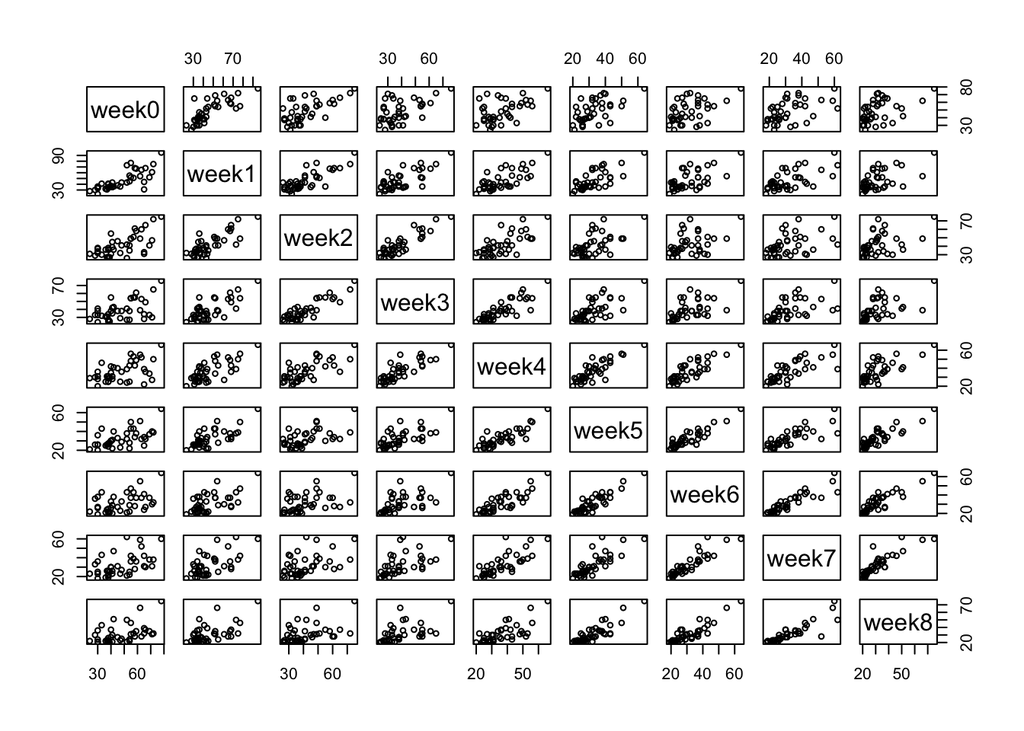

```r
# load the data in wide form and draw a scatter plot matrix
bprs_wide <- read.table("data/bprs_wide.csv", sep = ";")
pairs(bprs_wide[, 3:11], cex = 0.7)
```

### 6.2.3 Regression modeling

Now I’ll fit a linear regression model in which the BPRS is the response variable and time and treatment are the explanatory variables. It should be noted, that in this independent model the repeated-measures structure of the data is ignored. According to the results (see below) the estimate of time is statistical significant (p < 0.001), meaning that the BPRS scores decrease over time conditional on treatment group. However, the regression coefficient of treatment group is not significant indicating that the BPRS scores do not differ between the groups conditional on time.

```r
# fit random intercept model
bprs_m1 <- lm(bprs ~ week + treatment, data = bprs_long)
summary(bprs_m1)
```

```
##
## Call:
## lm(formula = bprs ~ week + treatment, data = bprs_long)
##
## Residuals:
##     Min      1Q  Median      3Q     Max
## -22.454  -8.965  -3.196   7.002  50.244
##
## Coefficients:
##             Estimate Std. Error t value Pr(>|t|)
## (Intercept)  46.4539     1.3670  33.982   <2e-16 ***
## week         -2.2704     0.2524  -8.995   <2e-16 ***
## treatment2    0.5722     1.3034   0.439    0.661
## ---
## Signif. codes:  0 '***' 0.001 '**' 0.01 '*' 0.05 '.' 0.1 ' ' 1
##
## Residual standard error: 12.37 on 357 degrees of freedom
## Multiple R-squared:  0.1851, Adjusted R-squared:  0.1806
## F-statistic: 40.55 on 2 and 357 DF,  p-value: < 2.2e-16
```

The independent model conducted above assumes an independence of the measures of the response variable (bprs), which is highly unlikely here. Thus, I will fit a random intercept model, which allows the linear regression fit for each participant to differ in intercept from other participants.

```r
# access to lme4-package that provide functions for fitting mixed models
library("lme4")

# to add p-values to the summary
#install.packages("lmerTest")
library(lmerTest)

# note: in the formula the random-effects terms distinguished by vertical bars (|)
bprs_rim1 <- lmer(bprs ~ week + treatment + (1 | id), data = bprs_long, REML = FALSE)

# summary of the random intercept model
summary(bprs_rim1)
```

```
## Linear mixed model fit by maximum likelihood . t-tests use Satterthwaite's
##   method [lmerModLmerTest]
## Formula: bprs ~ week + treatment + (1 | id)
##    Data: bprs_long
##
##      AIC      BIC   logLik deviance df.resid
##   2582.9   2602.3  -1286.5   2572.9      355
##
## Scaled residuals:
##      Min       1Q   Median       3Q      Max
## -2.27506 -0.59909 -0.06104  0.44226  3.15835
##
## Random effects:
##  Groups   Name        Variance Std.Dev.
##  id       (Intercept) 97.39    9.869
##  Residual             54.23    7.364
## Number of obs: 360, groups:  id, 40
##
## Fixed effects:
##             Estimate Std. Error       df t value Pr(>|t|)
## (Intercept)  46.4539     2.3521  45.7607  19.750   <2e-16 ***
## week         -2.2704     0.1503 320.0000 -15.104   <2e-16 ***
## treatment2    0.5722     3.2159  40.0000   0.178     0.86
## ---
## Signif. codes:  0 '***' 0.001 '**' 0.01 '*' 0.05 '.' 0.1 ' ' 1
##
## Correlation of Fixed Effects:
##            (Intr) week
## week       -0.256
## treatment2 -0.684  0.000
```

The results from the random intercept model are presented above. The estimates of time (i.e. week) and treatment group are quite similar to those from the previous model. The p-value of the time’s estimate is statistically significant, while in the case of treatment group it is not. The magnitudes of the t-values provide similar evidence as the magnitude of week’s t-value (-15.1) is quite large, while the magnitude of treatment’s t-value (0.2) is really small (see Note 1 below). Interpretation is the same as above, that the results suggest that the BPRS scores decrease by time conditional on treatment.

The estimated variance of the participant (id) random effects is pretty large (97.39), which indicates considerable variation in the intercepts of the regression fits of the individual BPRS profiles. Thus, I will next fit a random intercept and random slope model, which allows the linear regression fits for each individual to differ in slope as well. This way it is possible to detect the individual differences in the participants’ BPRS profiles, and also the effect of time.

*Note 1:* The greater is the magnitude of t-value, the greater is the evidence against the null hypothesis, that is: the greater evidence that there is a significant difference. Respectively, the closer t is to 0, the more likely there is not a statistically significant difference.

*Note 2:* Even though the significance of the results or coefficients of the mixed effect models is commented multiple times in the chapter 9 of MABS, there are no p-values or explanations how to interpret the significance of the results from the t-values, which I found a bit annoying. Here, I installed *lmerTest*-package which adds p-values to the lrm-summary tables.

```r
# random intercept and random slope model
bprs_rim2 <- lmer(bprs ~ week + treatment + (week | id), data = bprs_long, REML = FALSE)

# summary of the random intercept and slope model
summary(bprs_rim2)
```

```
## Linear mixed model fit by maximum likelihood . t-tests use Satterthwaite's
##   method [lmerModLmerTest]
## Formula: bprs ~ week + treatment + (week | id)
##    Data: bprs_long
##
##      AIC      BIC   logLik deviance df.resid
##   2523.2   2550.4  -1254.6   2509.2      353
##
## Scaled residuals:
##     Min      1Q  Median      3Q     Max
## -2.4655 -0.5150 -0.0920  0.4347  3.7353
##
## Random effects:
##  Groups   Name        Variance Std.Dev. Corr
##  id       (Intercept) 167.827  12.955
##           week          2.331   1.527   -0.67
##  Residual              36.747   6.062
## Number of obs: 360, groups:  id, 40
##
## Fixed effects:
##             Estimate Std. Error      df t value Pr(>|t|)
## (Intercept)  45.9830     2.6470 49.9491  17.372  < 2e-16 ***
## week         -2.2704     0.2713 40.0001  -8.370 2.51e-10 ***
## treatment2    1.5139     3.1392 39.9998   0.482    0.632
## ---
## Signif. codes:  0 '***' 0.001 '**' 0.01 '*' 0.05 '.' 0.1 ' ' 1
##
## Correlation of Fixed Effects:
##            (Intr) week
## week       -0.545
## treatment2 -0.593  0.000
```

```r
# anova
anova(bprs_rim1, bprs_rim2)
```

```
## Data: bprs_long
## Models:
## bprs_rim1: bprs ~ week + treatment + (1 | id)
## bprs_rim2: bprs ~ week + treatment + (week | id)
##           npar    AIC    BIC  logLik deviance  Chisq Df Pr(>Chisq)
## bprs_rim1    5 2582.9 2602.3 -1286.5   2572.9
## bprs_rim2    7 2523.2 2550.4 -1254.6   2509.2 63.663  2  1.499e-14 ***
## ---
## Signif. codes:  0 '***' 0.001 '**' 0.01 '*' 0.05 '.' 0.1 ' ' 1
```

The results from the random intercept and random slope model are presented above. The fixed effect estimate of time (i.e. week) is the same as in the random intercept model, but the fixed effect estimate of treatment group is larger, suggesting bigger difference in the BPRS scores between the groups. However, as can be seen from the summary table, according to the p-values the estimate of treatment is not statistically significant, while estimate of time is and the t-values provide similar evidence.

```r
# random intercept and random slope model with an interation term
bprs_rim3 <- lmer(bprs ~ week * treatment + (week | id), data = bprs_long, REML = FALSE)
# summary of the model
summary(bprs_rim3)
```

```
## Linear mixed model fit by maximum likelihood . t-tests use Satterthwaite's
##   method [lmerModLmerTest]
## Formula: bprs ~ week * treatment + (week | id)
##    Data: bprs_long
##
##      AIC      BIC   logLik deviance df.resid
##   2523.5   2554.5  -1253.7   2507.5      352
##
## Scaled residuals:
##     Min      1Q  Median      3Q     Max
## -2.4747 -0.5256 -0.0866  0.4435  3.7884
##
## Random effects:
##  Groups   Name        Variance Std.Dev. Corr
##  id       (Intercept) 164.204  12.814
##           week          2.203   1.484   -0.66
##  Residual              36.748   6.062
## Number of obs: 360, groups:  id, 40
##
## Fixed effects:
##                 Estimate Std. Error      df t value Pr(>|t|)
## (Intercept)      47.8856     2.9840 40.0010  16.047  < 2e-16 ***
## week             -2.6283     0.3752 40.0021  -7.006 1.84e-08 ***
## treatment2       -2.2911     4.2200 40.0010  -0.543    0.590
## week:treatment2   0.7158     0.5306 40.0021   1.349    0.185
## ---
## Signif. codes:  0 '***' 0.001 '**' 0.01 '*' 0.05 '.' 0.1 ' ' 1
##
## Correlation of Fixed Effects:
##             (Intr) week   trtmn2
## week        -0.668
## treatment2  -0.707  0.473
## wek:trtmnt2  0.473 -0.707 -0.668
```

```r
# anova
anova(bprs_rim2, bprs_rim3)
```

```
## Data: bprs_long
## Models:
## bprs_rim2: bprs ~ week + treatment + (week | id)
## bprs_rim3: bprs ~ week * treatment + (week | id)
##           npar    AIC    BIC  logLik deviance Chisq Df Pr(>Chisq)
## bprs_rim2    7 2523.2 2550.4 -1254.6   2509.2
## bprs_rim3    8 2523.5 2554.6 -1253.7   2507.5  1.78  1     0.1821
```

The very last thing to do is to draw one more figure which shows the observed and fitted BPRS profiles. Based on the above presented results I will use the random intercept and slope model without interaction term for fitting values. The two figures are presented below. They illustrate how well the model fits the observed data. Model seems to fit somewhat roughly and there are also quite big differences between the observed and fitted lines, but everyone can take a look and make a judgement of their own.

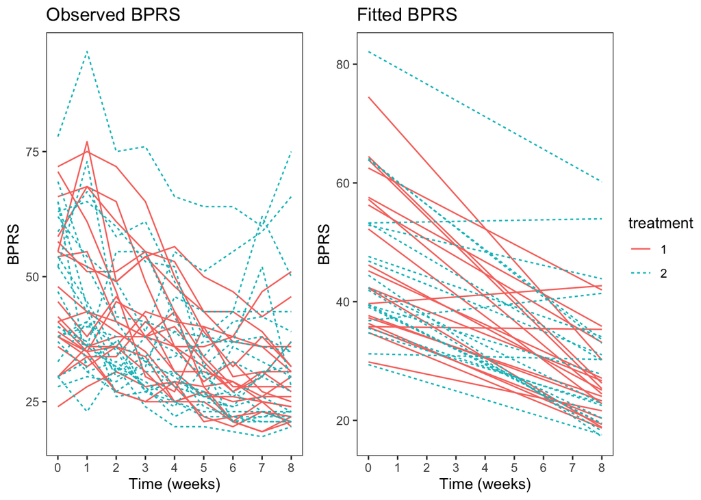

```r
# create fitted data
Fitted <- fitted(bprs_rim2)

# add the fitted values to the data frame
 bprs_long <- bprs_long %>%
   mutate(Fitted = Fitted)

graph1 <- ggplot(bprs_long , aes(x = week, y = bprs, group = id, col = treatment)) +
  geom_line(aes(linetype = treatment)) +
  scale_x_continuous(name = "Time (weeks)", breaks = seq(0, 11, 1)) +
  scale_y_continuous(name = "BPRS") +
  theme_bw() + theme(legend.position = "right") +
  theme(panel.grid.major = element_blank(), panel.grid.minor = element_blank()) +
  ggtitle("Observed BPRS")

graph2 <- ggplot(bprs_long , aes(x = week, y = Fitted, group = id, col = treatment)) +
  geom_line(aes(linetype = treatment)) +
  scale_x_continuous(name = "Time (weeks)", breaks = seq(0, 11, 1)) +
  scale_y_continuous(name = "BPRS") +
  theme_bw() + theme(legend.position = "right") +
  theme(panel.grid.major = element_blank(), panel.grid.minor = element_blank()) +
  ggtitle("Fitted BPRS")

library(ggpubr)
ggarrange(graph1, graph2,
          ncol = 2, nrow = 1,
          common.legend = TRUE, legend = "right")
```

**THAT’S**

*ALL* *FOLKS* *AND* *DOCS!*

**THE END.**